# Integrating Computation Into Statistics Courses: Worked Example

Empirical Investigation

Alex Stringer

2018-05-22

```r
# Load the tidyverse packages
suppressMessages({
  suppressWarnings({
    library(tidyverse)
  })
})
```

## Simulate One Experiment (Basic)

Using mostly base `R`, students may be guided to produce the following result:

```r
# Function to perform one experiment
perform_one_experiment_basic <- function(k,N=5000,p=0.05) {
  n <- N / k

  # Simulate the population
  popsim <- numeric(N)
  for (i in 1:N) {
    popsim[i] <- rbinom(n = 1,size = 1,prob = p)
  }

  # Group them
  groups <- rep(1:n,k)

  # Check the disease status of each group
  any_diseased <- numeric(n)
  for (i in 1:N) {
    if (popsim[i] == 1) {
      any_diseased[groups[i]] <- 1
    }
  }

  # Count the number of tests performed
  numtests <- 0
  for (i in 1:n) {
    if (any_diseased[i] == 1) {
      numtests <- numtests + (k + 1)
    }
    else {
      numtests <- numtests + 1
    }
  }
  numtests
}

perform_one_experiment_basic(5)
```

```
## [1] 2195
```

## Simulate One Experiment (Advanced)

If the instructor wishes to introduce or otherwise make use of more advanced programming constructs in `R`, this example can be used for this purpose by extending the above “basic” simulation to include the use of more advanced data structures and some light functional programming:

```r
# Function to check inputs: same as above
# Function to perform one experiment
perform_one_experiment_advanced <- function(k,N=5000,p=0.05) {
  n <- N / k
  data_frame(disease = rbinom(N,1,p),
             group = rep(1:n,k)) %>%
    group_by(group) %>%
    summarize(disease = max(disease)) %>%
    mutate(numtests = k*disease + 1) %>%
    summarize(numtests = sum(numtests)) %>%
    pull(numtests)
}

perform_one_experiment_advanced(5)
```

```
## [1] 2115
```

## Simulate Many Experiments

Analogous to the manner in which the single-experiment simulation is coded, there are two immediate ways to perform the multiple simulations desired:

```r
# Two functions to perform B experiments for fixed k and average the result
#
# Basic
perform_B_experiments_basic <- function(B,k,N=5000,p=0.05) {
  results <- numeric(B)
  for (i in 1:B) {
    results[i] <- perform_one_experiment_basic(k,N,p)
  }
  mean(results)
}

perform_B_experiments_basic(25,5)
```

```
## [1] 2123
```

```r
# Advanced
perform_B_experiments_advanced <- function(B,k,N=5000,p=0.05) {
  map(1:B,~perform_one_experiment_advanced(k,N,p)) %>%
    reduce(c) %>%
    mean()
}

perform_B_experiments_advanced(25,5)
```

```
## [1] 2114.4
```

We can then make a `ggplot` plot of the empirically-estimated number of experiements required for each value of k as follows. `ggplot` is worth introducing to students at any level as it allows them to create publication-quality plots:

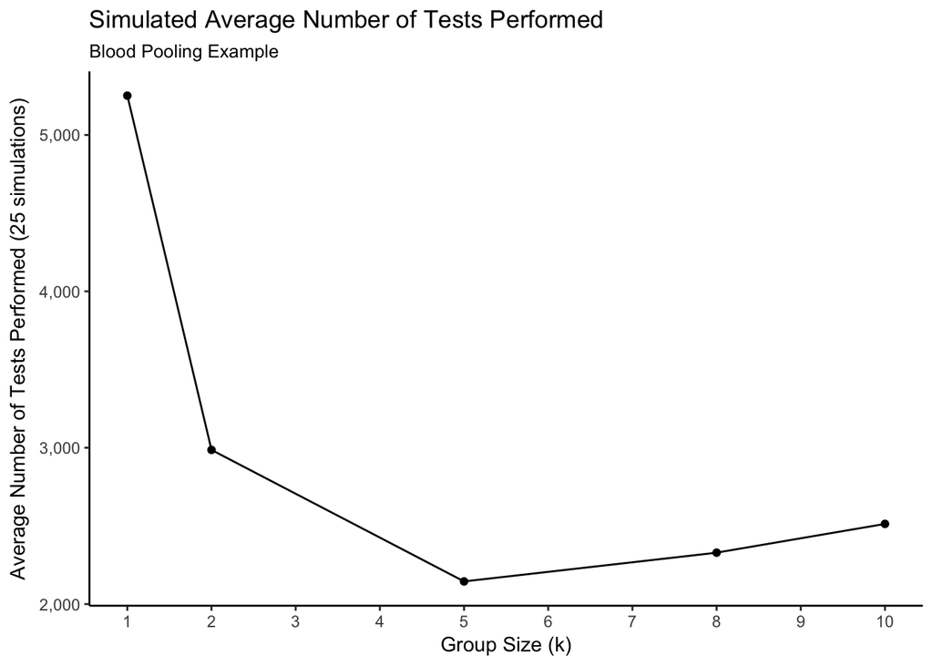

```r
# Simulate for valid values of k from 1 to 10:
sim_results <- numeric(5)
k_to_do <- c(1,2,5,8,10)
for (i in 1:length(k_to_do)) {
  sim_results[i] <- perform_B_experiments_basic(25,k_to_do[i])
}
# ggplot needs its input to be a data_frame
sim_results <- data_frame(k = k_to_do,numtests_sim = sim_results)


# Or...
sim_results <- c(1,2,5,8,10) %>%
  map(~data_frame(k = .x,numtests_sim = perform_B_experiments_advanced(25,.x))) %>%
  reduce(bind_rows)

sim_results %>%
  ggplot(aes(x = k,y = numtests_sim,group = 1)) +
  theme_classic() +
  geom_point() +
  geom_line() +
  labs(title = "Simulated Average Number of Tests Performed",
       subtitle = "Blood Pooling Example",
       x = "Group Size (k)",
       y = "Average Number of Tests Performed (25 simulations)") +
  scale_x_continuous(breaks = 1:10) +
  scale_y_continuous(labels = scales::comma_format())
```

This give students a feel for the problem that will help to guide our analytical solution: the number of tests starts high with low $k$ (pooling doesn’t reduce the number of tests that much when the groups only have a couple people in them), then decreases as $k$ increases, but then starts increasing again, as the groups become large enough that most of them end up having a diseased individual, and therefore do not produce a reduction in the number of tests performed. From the simulations, we see that $k = 5$ is a likely candidate for the group size that minimizes the expected number of tests.